# CHF Safe-Haven Effect - Macroeconometrics Project

# 1 Introduction

This project investigates the safe-haven effect of the Swiss Franc (CHF) during major geopolitical crises. We test whether global geopolitical risk shocks cause capital inflows into Switzerland independently of traditional financial dynamics such as interest rate differentials.

Our main hypothesis is that a positive shock to the GPR Index leads to statistically significant increase in portfolio investment inflows into Switzerland from foreign countries. Therefore, we should observe a “pure-fear” safe-haven effect that cannot be explained by carry trade logic alone. We control for the carry trade channel through the US-CH yield spread. The S&P 500 was considered as an additional control for financial panic but was excluded to preserve degrees of freedom given our sample size, and since the yield spread already partially reflects broader financial stress. Including the S&P 500 would reduce degrees of freedom without meaningfully improving identification, given the fact that there is an overlap between equity market stress and yield spread dynamics.

# 2 Data

## 2.1 Variables and Sources used

We decided to use quarterly data covering the time period 1985-Q1 to 2025-Q4. The dataset contains the following variables:

- **GPR Index**: Global Geopolitical Risk Index (Caldara & Iacoviello, 2022). Measures monthly adverse geopolitical events and associated risks. It quantifies the intensity of global tensions based on newspaper coverage of war, terrorism, and international disputes.
- **Portfolio inflows Switzerland**: Net incurrence of portfolio investment liabilities (SNB Balance of Payments). This is our main dependent variable capturing safe-haven capital flows into Switzerland.
- **US-CH yield spread**: The difference between US and Swiss 10-year government bond yields. Controls for the carry trade channel — the primary alternative explanation for CHF inflows.
- **SNB FX reserves change** *(Model B only)*: Quarterly change in SNB foreign exchange reserves. Controls for mechanical flows generated by SNB interventions, particularly visible after the 2022 policy reversal.

## 2.2 Sample periods

We estimate two models with different sample periods:

- **Model A (main model)**: 1985-Q1 to 2025-Q4; full sample, 3 variables (GPR, yield spread, portfolio inflows)
- **Model B (robustness)**: 1997-Q1 to 2025-Q4; includes SNB FX reserves change as 4th control variable to absorb mechanical central bank flows

The SNB FX reserves data is only available from 1996-Q4, which is why Model B starts in 1997-Q1.

# 3 Data Loading

## 3.1 Packages

We begin by installing and loading all required R packages.

```r
pkgs <- c("tidyverse", "readxl", "vars", "urca",
          "tseries", "ggplot2", "patchwork", "scales",
          "strucchange", "knitr", "kableExtra", "moments", "gt",
          "ggtext")

for (p in pkgs) {
  if (!p %in% rownames(installed.packages())) install.packages(p)
}

library(tidyverse)
library(readxl)
library(vars)
library(urca)
library(tseries)
library(ggplot2)
library(patchwork)
library(scales)
library(strucchange)
library(knitr)
library(kableExtra)
library(moments)
library(gt)
library(ggtext)

# Presentation-ready theme used across all plots
theme_chf <- function() {
  theme_minimal(base_size = 13) +
  theme(
    plot.title       = element_text(face = "bold", size = 13),
    plot.subtitle    = element_text(size = 10, color = "grey40"),
    axis.title       = element_text(size = 10, color = "grey30"),
    axis.text        = element_text(size = 9,  color = "grey30"),
    panel.grid.major = element_line(color = "grey92", linewidth = 0.4),
    panel.grid.minor = element_blank(),
    plot.background  = element_rect(fill = "white", color = NA),
    panel.background = element_rect(fill = "white", color = NA),
    strip.text       = element_text(face = "bold", size = 11),
    legend.position  = "bottom",
    plot.margin      = margin(10, 15, 10, 15)
  )
}
```

## 3.2 GPR Index

The GPR Index is downloaded and we use the global GPR column and convert the quarter label to a proper date format.

```r
gpr <- read_excel("data_gpr_quarterly.xlsx", sheet = "Sheet1") %>%
  dplyr::select(quarter, GPR) %>%
  mutate(
    year  = as.integer(substr(quarter, 1, 4)),
    q     = as.integer(substr(quarter, 6, 6)),
    month = (q - 1) * 3 + 1,
    date  = as.Date(paste(year, month, "01", sep = "-"))
  ) %>%
  dplyr::select(date, GPR)

head(gpr)
```

```
# A tibble: 6 × 2
  date         GPR
  <date>     <dbl>
1 1985-01-01 115.
2 1985-04-01 113.
3 1985-07-01 106.
4 1985-10-01  99.1
5 1986-01-01 111.
6 1986-04-01 121.
```

## 3.3 Portfolio Inflows (dependent variable)

Net portfolio investment inflows into Switzerland from the SNB Balance of Payments. Positive values indicate net foreign purchases of Swiss assets (safe-haven inflows). Negative values indicate net foreign sales.

```r
pip <- read_excel("snb_portfolio_inflows.xlsx",
                  sheet = "R_import", skip = 4) %>%
  dplyr::select(date = 2, pip_total = 3) %>%
  mutate(date = as.Date(date))

head(pip)
```

```
# A tibble: 6 × 2
  date       pip_total
  <date>         <dbl>
1 1985-01-01     2324.
2 1985-04-01     3105.
3 1985-07-01     3741.
4 1985-10-01     4173.
5 1986-01-01     4354.
6 1986-04-01     4309.
```

## 3.4 SNB FX Reserves

End of quarter stock level and quarterly change. Used in Model B only.

```r
fx_res <- read_excel("snb_fx_reserves_quarterly.xlsx",
                     sheet = "Quarterly (End of Period)", skip = 5) %>%
  dplyr::select(date = 2, fx_reserves_eop = 3, d_fx_reserves = 4) %>%
  mutate(
    date          = as.Date(date),
    d_fx_reserves = as.numeric(d_fx_reserves) / 1000  # rescaled to CHF billions
  )

head(fx_res)
```

```
# A tibble: 6 × 3
  date       fx_reserves_eop d_fx_reserves
  <date>               <dbl>         <dbl>
1 1996-10-01          49328.       NA
2 1997-01-01          48885        -0.443
3 1997-04-01          48304        -0.581
4 1997-07-01          48314.        0.0096
5 1997-10-01          53271.        4.96
6 1998-01-01          49400.       -3.87
```

## 3.5 Yield Spread

The yield spread is the difference between the US and Swiss 10-year government bond yields, expressed in percentage points. It controls for the carry trade channel.

```r
spread <- read_excel("US_CH_10Y_spread_clean.xlsx",
                     sheet = "Quarterly", skip = 5) %>%
  dplyr::select(date = 2, spread = 5) %>%
  mutate(date = as.Date(date))

head(spread)
```

```
# A tibble: 6 × 2
  date       spread
  <date>      <dbl>
1 1985-01-01   6.76
2 1985-04-01   6.06
3 1985-07-01   5.64
4 1985-10-01   5.27
5 1986-01-01   4.29
6 1986-04-01   3.24
```

## 3.6 S&P 500

Loaded for variable selection testing only (Section 4). Not included in any final VAR model specification.

```r
sp500 <- read_excel("S&P500_clean_quarterly.xlsx",
                    sheet = "Quarterly", skip = 4) %>%
  dplyr::select(date = 2, sp500 = 3) %>%
  mutate(
    date = as.Date(date),
    date = as.Date(paste0(
      format(date, "%Y"), "-",
      sprintf("%02d", ((as.integer(format(date, "%m")) - 1) %/% 3) * 3 + 1),
      "-01"))
  )

head(sp500)
```

```
# A tibble: 6 × 2
  date       sp500
  <date>     <dbl>
1 1985-01-01  181.
2 1985-04-01  192.
3 1985-07-01  182.
4 1985-10-01  211.
5 1986-01-01  239.
6 1986-04-01  251.
```

## 3.7 Merge all variables

We merge all datasets by date into a single quarterly panel. All variables are aligned by the first day of each quarter.

```r
df <- pip %>%
  left_join(gpr,    by = "date") %>%
  left_join(spread, by = "date") %>%
  left_join(fx_res, by = "date") %>%
  left_join(sp500,  by = "date") %>%
  arrange(date)

cat("Dimensions:", nrow(df), "rows x", ncol(df), "columns\n")
```

```
Dimensions: 164 rows x 7 columns
```

```r
cat("Date range:", as.character(min(df$date)),
    "to", as.character(max(df$date)), "\n")
```

```
Date range: 1985-01-01 to 2025-10-01
```

```r
cat("\nNA count per column:\n")
```

```
NA count per column:
```

```r
print(colSums(is.na(df)))
```

```
           date       pip_total             GPR          spread fx_reserves_eop
              0               0               0               0              47
  d_fx_reserves           sp500
             48               0
```

## 3.8 Additional Data Verification

```r
cat("First 6 rows:\n");      print(head(df))
```

```
First 6 rows:
```

```
# A tibble: 6 × 7
  date       pip_total   GPR spread fx_reserves_eop d_fx_reserves sp500
  <date>         <dbl> <dbl>  <dbl>           <dbl>         <dbl> <dbl>
1 1985-01-01     2324. 115.    6.76              NA            NA  181.
2 1985-04-01     3105. 113.    6.06              NA            NA  192.
3 1985-07-01     3741. 106.    5.64              NA            NA  182.
4 1985-10-01     4173.  99.1   5.27              NA            NA  211.
5 1986-01-01     4354. 111.    4.29              NA            NA  239.
6 1986-04-01     4309. 121.    3.24              NA            NA  251.
```

```r
cat("\nLast 6 rows:\n");     print(tail(df))
```

```
Last 6 rows:
```

```
# A tibble: 6 × 7
  date       pip_total   GPR spread fx_reserves_eop d_fx_reserves sp500
  <date>         <dbl> <dbl>  <dbl>           <dbl>         <dbl> <dbl>
1 2024-07-01    -1911.  121.   3.51         738257.         7.33  5762.
2 2024-10-01     6243.  134.   3.93         754160.        15.9   5882.
3 2025-01-01     9253.  141.   4.02         753956.        -0.204 5612.
4 2025-04-01   -11316.  176.   4.03         744756.        -9.2   6205.
5 2025-07-01     -388.  133.   3.96         764974.        20.2   6688.
6 2025-10-01    24512.  130.   3.87         759210.        -5.76  6846.
```

```r
cat("\nBasic statistics:\n"); print(summary(df))
```

```
Basic statistics:
```

```
      date              pip_total             GPR             spread
 Min.   :1985-01-01   Min.   :-45418.3   Min.   : 46.32   Min.   :-0.051
 1st Qu.:1995-03-09   1st Qu.:  -945.1   1st Qu.: 81.70   1st Qu.: 1.486
 Median :2005-05-16   Median :  1878.4   Median : 92.82   Median : 2.062
 Mean   :2005-05-16   Mean   :   957.6   Mean   :102.88   Mean   : 2.250
 3rd Qu.:2015-07-24   3rd Qu.:  3727.0   3rd Qu.:111.53   3rd Qu.: 2.581
 Max.   :2025-10-01   Max.   : 48848.8   Max.   :351.81   Max.   : 6.756

 fx_reserves_eop  d_fx_reserves          sp500
 Min.   : 43785   Min.   :-76.0323   Min.   : 180.7
 1st Qu.: 50581   1st Qu.: -2.3904   1st Qu.: 533.7
 Median :226658   Median :  0.9388   Median :1218.2
 Mean   :369840   Mean   :  6.1197   Mean   :1644.4
 3rd Qu.:741202   3rd Qu.: 12.4218   3rd Qu.:2060.6
 Max.   :966202   Max.   :119.5572   Max.   :6845.5
 NA's   :47       NA's   :48
```

## 3.9 Descriptive Analysis

```r
descriptive_stats_tbl <- df %>%
  dplyr::select(
    `Portfolio Inflows (CHF mn)` = pip_total,
    `GPR Index`                  = GPR,
    `Yield Spread (pp)`          = spread,
    `Δ FX Reserves (CHF bn)`     = d_fx_reserves
  ) %>%
  pivot_longer(everything(), names_to = "Variable", values_to = "value") %>%
  group_by(Variable) %>%
  summarise(
    Obs        = sum(!is.na(value)),
    Mean       = round(mean(value,              na.rm = TRUE), 2),
    Median     = round(median(value,            na.rm = TRUE), 2),
    `Std. Dev` = round(sd(value,                na.rm = TRUE), 2),
    Min        = round(min(value,               na.rm = TRUE), 2),
    Max        = round(max(value,               na.rm = TRUE), 2),
    Skewness   = round(moments::skewness(value, na.rm = TRUE), 2)
  ) %>%
  slice(match(c("Portfolio Inflows (CHF mn)",
                "GPR Index",
                "Yield Spread (pp)",
                "Δ FX Reserves (CHF bn)"), Variable))

descriptive_stats_tbl %>%
  gt() %>%
  tab_header(
    title    = md("**Table 1 — Descriptive Statistics**"),
    subtitle = md("*Quarterly data · Full sample 1985–2025 · Raw untransformed variables*")
  ) %>%
  cols_label(
    Variable  = "Variable",
    Obs       = "Obs.",
    Mean      = "Mean",
    Median    = "Median",
    `Std. Dev`= "Std. Dev",
    Min       = "Min",
    Max       = "Max",
    Skewness  = "Skewness"
  ) %>%
  cols_align(align = "left",   columns = Variable) %>%
  cols_align(align = "center", columns = c(Obs, Mean, Median,
                                            `Std. Dev`, Min, Max, Skewness)) %>%
  cols_width(
    Variable   ~ px(200),
    Obs        ~ px(55),
    Mean       ~ px(75),
    Median     ~ px(75),
    `Std. Dev` ~ px(75),
    Min        ~ px(75),
    Max        ~ px(75),
    Skewness   ~ px(75)
  ) %>%
  # Subtle alternating row shading
  tab_style(
    style     = cell_fill(color = "#f9f9f9"),
    locations = cells_body(rows = c(1, 3))
  ) %>%
  # LaTeX-style borders
  tab_style(
    style     = cell_borders(sides = "top",    color = "black", weight = px(2)),
    locations = cells_column_labels()
  ) %>%
  tab_style(
    style     = cell_borders(sides = "bottom", color = "black", weight = px(2)),
    locations = cells_column_labels()
  ) %>%
  tab_style(
    style     = cell_borders(sides = "bottom", color = "black", weight = px(2)),
    locations = cells_body(rows = 4)
  ) %>%
  tab_style(
    style     = cell_borders(sides = c("top", "bottom"),
                              color = "white", weight = px(0)),
    locations = cells_body(rows = 1:3)
  ) %>%
  tab_style(
    style     = cell_text(weight = "bold"),
    locations = cells_column_labels()
  ) %>%
  tab_source_note(
    md("*Note: Skewness > 0 indicates right-skewed distribution. Δ FX Reserves available from 1997-Q1 (116 obs.) and reported in CHF billions after rescaling in Section 2.4.*")
  ) %>%
  tab_options(
    table.font.size                 = px(13),
    table.border.top.style          = "hidden",
    table.border.bottom.style       = "hidden",
    row.striping.include_table_body = FALSE,
    column_labels.background.color  = "white",
    table_body.hlines.style         = "none",
    heading.border.bottom.style     = "none",
    table.width                     = pct(100)
  )
```

**Table 1 — Descriptive Statistics**

*Quarterly data · Full sample 1985–2025 · Raw untransformed variables*

| Variable | Obs. | Mean | Median | Std. Dev | Min | Max | Skewness |
| --- | --- | --- | --- | --- | --- | --- | --- |
| Portfolio Inflows (CHF mn) | 164 | 957.62 | 1878.39 | 9002.35 | -45418.31 | 48848.81 | 0.06 |
| GPR Index | 164 | 102.88 | 92.82 | 40.43 | 46.32 | 351.81 | 2.82 |
| Yield Spread (pp) | 164 | 2.25 | 2.06 | 1.13 | -0.05 | 6.76 | 1.31 |
| Δ FX Reserves (CHF bn) | 116 | 6.12 | 0.94 | 26.76 | -76.03 | 119.56 | 1.45 |

# 4 Variable Transformations

Before we are able to estimate the VAR we need to transform the raw variables. Variables that are non-stationary must be converted to first differences. We also apply log transformations to compress the scale of variables with large values.

The yield spread enters the VAR in levels since it is most likely already stationary because interest rate spreads tend to mean-revert over time. We will confirm this formally in Section 7 with unit root tests.

```r
df <- df %>%
  mutate(
    ln_pip     = log(abs(pip_total) + 1) * sign(pip_total),
    ln_gpr     = log(GPR),
    ln_sp500   = log(sp500),
    d_ln_pip   = c(NA, diff(ln_pip)),
    d_ln_gpr   = c(NA, diff(ln_gpr)),
    d_ln_sp500 = c(NA, diff(ln_sp500))
  )

df %>%
  dplyr::select(date, pip_total, d_ln_pip, GPR, d_ln_gpr, spread) %>%
  summary()
```

```
      date              pip_total           d_ln_pip              GPR
 Min.   :1985-01-01   Min.   :-45418.3   Min.   :-21.38929   Min.   : 46.32
 1st Qu.:1995-03-09   1st Qu.:  -945.1   1st Qu.: -1.27862   1st Qu.: 81.70
 Median :2005-05-16   Median :  1878.4   Median : -0.01881   Median : 92.82
 Mean   :2005-05-16   Mean   :   957.6   Mean   :  0.01445   Mean   :102.88
 3rd Qu.:2015-07-24   3rd Qu.:  3727.0   3rd Qu.:  1.21129   3rd Qu.:111.53
 Max.   :2025-10-01   Max.   : 48848.8   Max.   : 20.21131   Max.   :351.81
                                         NA's   :1
    d_ln_gpr              spread
 Min.   :-1.1519423   Min.   :-0.051
 1st Qu.:-0.1172432   1st Qu.: 1.486
 Median :-0.0173230   Median : 2.062
 Mean   : 0.0007729   Mean   : 2.250
 3rd Qu.: 0.0993282   3rd Qu.: 2.581
 Max.   : 1.2263351   Max.   : 6.756
 NA's   :1
```

## 4.1 Variable Units — Reference Summary

The table below consolidates the units of all variables in both their raw and transformed forms. All downstream results (VAR coefficients, IRF values, forecast errors) are expressed in these units and should be interpreted accordingly.

| Variable | Raw Unit | Transformation | VAR Unit | Interpretation |
| --- | --- | --- | --- | --- |
| Portfolio Inflows | CHF millions | log → first difference | Δ ln(pip) | Quarter-on-quarter % change in inflows |
| GPR Index | Dimensionless index | log → first difference | Δ ln(GPR) | Quarter-on-quarter % change in GPR |
| Yield Spread | Percentage points (pp) | none | levels (pp) | US 10Y minus Swiss 10Y yield in pp |
| Δ FX Reserves | CHF billions (after /1000) | none | levels (CHF bn) | Quarterly change in SNB reserves |
| Structural GPR shock SD | Dimensionless | from Cholesky | 0.2386 | ≈ 24% unexpected quarterly GPR increase |
| IRF y-axis | Δ ln(pip) units | scaled by SD | response units | Change in inflow growth per 1 SD GPR shock |
| VAR coefficients | Δ ln(pip) per unit | none | raw coefficient | Effect of 1 unit change in regressor |
| FEVD | % of variance | none | share (0–1) | Share of inflow variance explained by each shock |
| Bootstrap CI | Δ ln(pip) units | none | same as IRF | 90% confidence band around IRF point estimate |
| Companion root modulus | Dimensionless | none | 0–1 | Must be < 1 for VAR stability |
| R² | Dimensionless | none | 0–1 | Share of variance explained by model |
| Granger F-statistic | Dimensionless | none | F(8,438) | Joint test of all GPR lag coefficients = 0 |
| RMSE / MAE | Δ ln(pip) units | none | forecast error | Out-of-sample forecast accuracy |
| RMSE ratio | Dimensionless | none | 0.48 | VAR error / random walk error — < 1 means VAR wins |

**Key unit facts:**

# 5 Variable Selection Justification

We formally justify the exclusion of the S&P 500 from all model specifications. Two independent arguments support this decision: a statistical argument based on non-stationarity, and a theoretical argument based on the nature of our dependent variable.

## 5.1 Argument 1 — The S&P 500 is Non-Stationary

A VAR requires all included variables to be stationary. We test the S&P 500 index using the ADF test under both levels and first differences.

```r
# ADF helper function
run_adf_test <- function(series, variable_name, spec_type = "drift") {
  cleaned_series  <- na.omit(series)
  adf_result      <- ur.df(cleaned_series, type = spec_type, selectlags = "AIC")
  test_statistic  <- adf_result@teststat[1]
  critical_values <- adf_result@cval[1, ]

  tibble(
    Variable = variable_name,
    ADF_stat = round(test_statistic,           3),
    CV_1pct  = round(critical_values["1pct"],  3),
    CV_5pct  = round(critical_values["5pct"],  3),
    CV_10pct = round(critical_values["10pct"], 3),
    Decision = ifelse(test_statistic < critical_values["5pct"],
                      "Stationary", "Non-stationary")
  )
}

# Run ADF test on S&P 500
adf_sp500_results <- bind_rows(
  run_adf_test(df$ln_sp500,   "ln(S&P 500) — levels"),
  run_adf_test(df$d_ln_sp500, "Δ ln(S&P 500) — 1st difference")
)

adf_sp500_results %>%
  gt() %>%
  tab_header(
    title    = md("**ADF Unit Root Test: S&P 500**"),
    subtitle = md("*Drift specification · AIC lag selection · 5% significance threshold*")
  ) %>%
  cols_label(
    Variable = "Variable",
    ADF_stat = "ADF Statistic",
    CV_1pct  = "CV 1%",
    CV_5pct  = "CV 5%",
    CV_10pct = "CV 10%",
    Decision = "Decision"
  ) %>%
  cols_align(align = "left",   columns = Variable) %>%
  cols_align(align = "center", columns = c(ADF_stat, CV_1pct,
                                            CV_5pct, CV_10pct, Decision)) %>%
  cols_width(
    Variable ~ px(230),
    ADF_stat ~ px(100),
    CV_1pct  ~ px(70),
    CV_5pct  ~ px(70),
    CV_10pct ~ px(70),
    Decision ~ px(120)
  ) %>%
  tab_style(
    style     = cell_fill(color = "#f5f5f5"),
    locations = cells_body(rows = 1)
  ) %>%
  tab_style(
    style     = cell_fill(color = "#ffffff"),
    locations = cells_body(rows = 2)
  ) %>%
  # Stationary — green with check
  tab_style(
    style     = cell_text(color = "#2ca02c"),
    locations = cells_body(
      columns = Decision,
      rows    = Decision == "Stationary"
    )
  ) %>%
  tab_style(
    style     = cell_text(color = "#d62728"),
    locations = cells_body(
      columns = Decision,
      rows    = Decision == "Non-stationary"
    )
  ) %>%
  text_transform(
    locations = cells_body(
      columns = Decision,
      rows    = Decision == "Stationary"
    ),
    fn = function(x) paste0("<span style='color:#2ca02c'>✓ Stationary</span>")
  ) %>%
  text_transform(
    locations = cells_body(
      columns = Decision,
      rows    = Decision == "Non-stationary"
    ),
    fn = function(x) paste0("<span style='color:#d62728'>✗ Non-stationary</span>")
  ) %>%
  # LaTeX-style borders
  tab_style(
    style     = cell_borders(sides = "top",    color = "black", weight = px(2)),
    locations = cells_column_labels()
  ) %>%
  tab_style(
    style     = cell_borders(sides = "bottom", color = "black", weight = px(2)),
    locations = cells_column_labels()
  ) %>%
  tab_style(
    style     = cell_borders(sides = "bottom", color = "black", weight = px(2)),
    locations = cells_body(rows = 2)
  ) %>%
  tab_style(
    style     = cell_borders(sides = c("top", "bottom"),
                              color = "white", weight = px(0)),
    locations = cells_body(rows = 1)
  ) %>%
  tab_style(
    style     = cell_text(weight = "bold"),
    locations = cells_column_labels()
  ) %>%
  tab_source_note(
    md("*Note: H₀: unit root present. Reject H₀ if ADF statistic < CV 5% (−2.88). ln(S&P 500) in levels is non-stationary — it follows a random walk driven by long-run growth trends. Δ ln(S&P 500) in first differences is stationary, but including it would misrepresent its economic role as a control for equity market sentiment.*")
  ) %>%
  tab_options(
    table.font.size                 = px(13),
    table.border.top.style          = "hidden",
    table.border.bottom.style       = "hidden",
    row.striping.include_table_body = FALSE,
    column_labels.background.color  = "white",
    table_body.hlines.style         = "none",
    heading.border.bottom.style     = "none"
  )
```

**ADF Unit Root Test: S&P 500**

*Drift specification · AIC lag selection · 5% significance threshold*

| Variable | ADF Statistic | CV 1% | CV 5% | CV 10% | Decision |
| --- | --- | --- | --- | --- | --- |
| ln(S&P 500) — levels | -0.574 | -3.46 | -2.88 | -2.57 | ✗ Non-stationary |
| Δ ln(S&P 500) — 1st difference | -8.968 | -3.46 | -2.88 | -2.57 | ✓ Stationary |

*Note: H₀: unit root present. Reject H₀ if ADF statistic < CV 5% (−2.88). ln(S&P 500) in levels is non-stationary — it follows a random walk driven by long-run growth trends. Δ ln(S&P 500) in first differences is stationary, but including it would misrepresent its economic role as a control for equity market sentiment.*

The S&P 500 in levels is non-stationary since it follows a random walk driven by long-run growth trends. While applying first-differencing to the values we do achieve stationarity, but including Δ ln(S&P 500) would alter the variable’s economic interpretation. We would no longer be controlling for equity market sentiment, but for short-run return shocks, which is not the theoretically relevant quantity. Including a non-stationary variable in levels risks spurious regression. And including it in first-differenced form misrepresents its role. Either way, the S&P 500 is unsuitable for our VAR.

## 5.2 Argument 2 — Theoretical Irrelevance for Swiss Portfolio Inflows

Beyond the statistical argument, the S&P 500 is conceptually misaligned with our research question. Our dependent variable (portfolio investment inflows into Switzerland) captures foreign purchases of Swiss assets, motivated by the safe-haven properties of the CHF and Swiss financial markets. The S&P 500, as an stock market index tracking the performance of the 500 largest US-listed publicly traded corporations, reflects US equity market performance and domestic investor sentiment.

The safe-haven channel we study within this project operates through fear-driven capital flight into Switzerland, not through US equity dynamics. A global investor fleeing to safety responds to geopolitical risk (captured by GPR) and yield incentives (captured by the spread) and not to the level of US stock prices. Including the S&P 500 would fuse two distinct mechanisms: the safe-haven demand for CHF assets and US equity market performance, which are driven by largely independent forces.

We therefore exclude the S&P 500 from all model specifications on both statisticaland theoretical grounds.

# 6 Exploratory Data Analysis

Before we continue with the unit root tests and VAR, this section visually inspects the time series to identify trends, volatility patterns and the major crisis episodes that are central to the safe-haven hypothesis. The shaded areas mark the key geopolitical events of our sample.

We highlight especially the 10 below listed geopolitical events:

1. Gulf War 1990
2. Kosovo War 1999
3. 9/11 2001
4. Iraq War 2003
5. GFC 2008
6. Euro Crisis 2011
7. Crimea 2014
8. COVID-19 2020
9. Ukraine-Russia 2022
10. Gaza War 2023

## 6.1 Define Crisis Episodes within the Window

```r
crises <- tibble(
  label = c("Gulf War", "Kosovo War", "9/11", "Iraq War", "GFC",
            "Euro Crisis", "Crimea", "COVID-19", "Ukraine", "Gaza War"),
  start = as.Date(c("1990-08-01", "1999-03-01", "2001-09-01", "2003-03-01",
                    "2008-09-01", "2011-07-01", "2014-02-01", "2020-03-01",
                    "2022-02-01", "2023-10-01")),
  end   = as.Date(c("1991-02-01", "1999-06-01", "2002-01-01", "2003-12-01",
                    "2009-06-01", "2012-06-01", "2014-08-01", "2020-12-01",
                    "2022-12-01", "2025-01-01"))
)

add_crises <- function(p) {
  for (i in seq_len(nrow(crises))) {
    p <- p + annotate("rect",
      xmin = crises$start[i], xmax = crises$end[i],
      ymin = -Inf, ymax = Inf,
      fill = "#d62728", alpha = 0.12)
  }
  p
}
```

## 6.2 Portfolio Inflows

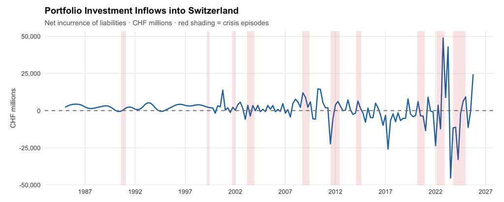

```r
p1 <- ggplot(df, aes(x = date, y = pip_total)) +
  geom_line(color = "#1f77b4", linewidth = 0.8) +
  geom_hline(yintercept = 0, linetype = "dashed", color = "grey50") +
  scale_x_date(date_breaks = "5 years", date_labels = "%Y") +
  scale_y_continuous(labels = comma) +
  labs(title    = "Portfolio Investment Inflows into Switzerland",
       subtitle = "Net incurrence of liabilities · CHF millions · red shading = crisis episodes",
       x = NULL, y = "CHF millions") +
  theme_chf()

add_crises(p1)
```

## 6.3 GPR Index

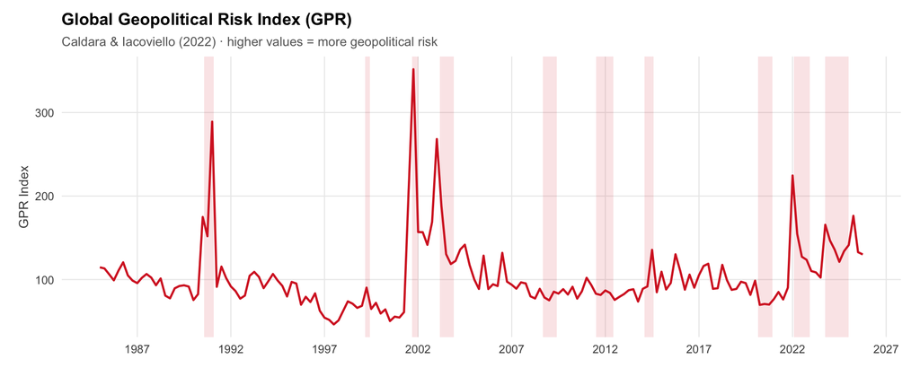

```r
p2 <- ggplot(df, aes(x = date, y = GPR)) +
  geom_line(color = "#d62728", linewidth = 0.8) +
  scale_x_date(date_breaks = "5 years", date_labels = "%Y") +
  labs(title    = "Global Geopolitical Risk Index (GPR)",
       subtitle = "Caldara & Iacoviello (2022) · higher values = more geopolitical risk",
       x = NULL, y = "GPR Index") +
  theme_chf()

add_crises(p2)
```

## 6.4 Yield Spread

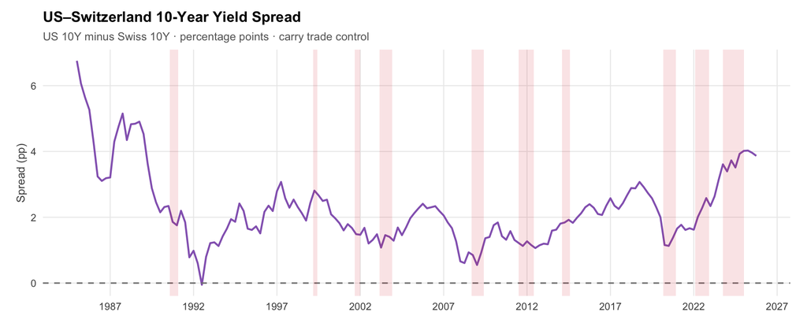

```r
p3 <- ggplot(df, aes(x = date, y = spread)) +
  geom_line(color = "#9467bd", linewidth = 0.8) +
  geom_hline(yintercept = 0, linetype = "dashed", color = "grey50") +
  scale_x_date(date_breaks = "5 years", date_labels = "%Y") +
  labs(title    = "US–Switzerland 10-Year Yield Spread",
       subtitle = "US 10Y minus Swiss 10Y · percentage points · carry trade control",
       x = NULL, y = "Spread (pp)") +
  theme_chf()

add_crises(p3)
```

## 6.5 SNB FX Reserves Change

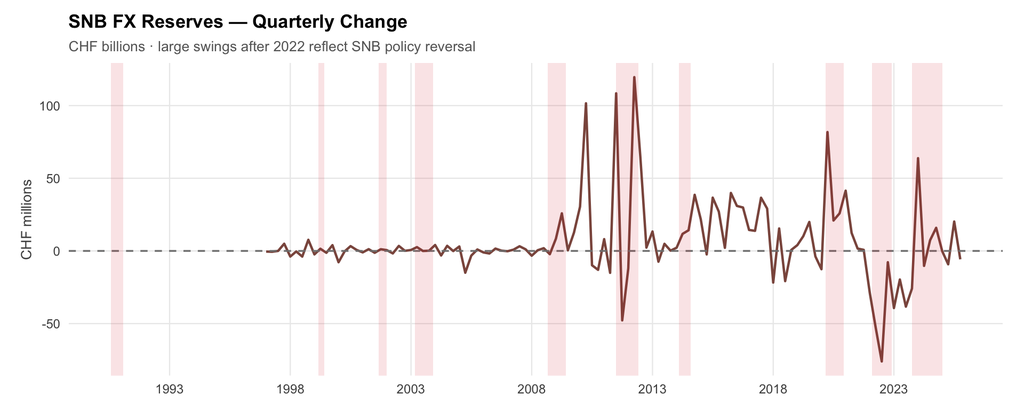

```r
p4 <- ggplot(df %>% filter(!is.na(d_fx_reserves)),
             aes(x = date, y = d_fx_reserves)) +
  geom_line(color = "#8c564b", linewidth = 0.8) +
  geom_hline(yintercept = 0, linetype = "dashed", color = "grey50") +
  scale_x_date(date_breaks = "5 years", date_labels = "%Y") +
  scale_y_continuous(labels = comma) +
  labs(title    = "SNB FX Reserves — Quarterly Change",
       subtitle = "CHF billions · large swings after 2022 reflect SNB policy reversal",
       x = NULL, y = "CHF millions") +
  theme_chf()

add_crises(p4)
```

## 6.6 All Variables — Combined Panel

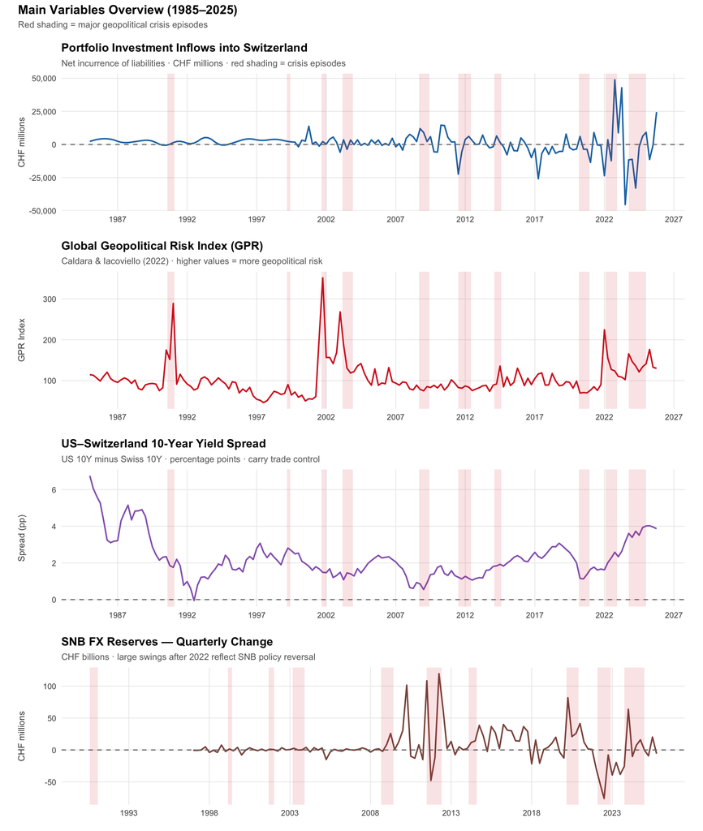

```r
(add_crises(p1) / add_crises(p2) / add_crises(p3) / add_crises(p4)) +
  plot_annotation(
    title    = "Main Variables Overview (1985–2025)",
    subtitle = "Red shading = major geopolitical crisis episodes",
    theme    = theme(
      plot.title    = element_text(size = 14, face = "bold"),
      plot.subtitle = element_text(size = 10, color = "grey40"),
      plot.background = element_rect(fill = "white", color = NA)
    )
  )
```

## 6.7 Transformed Series (VAR inputs)

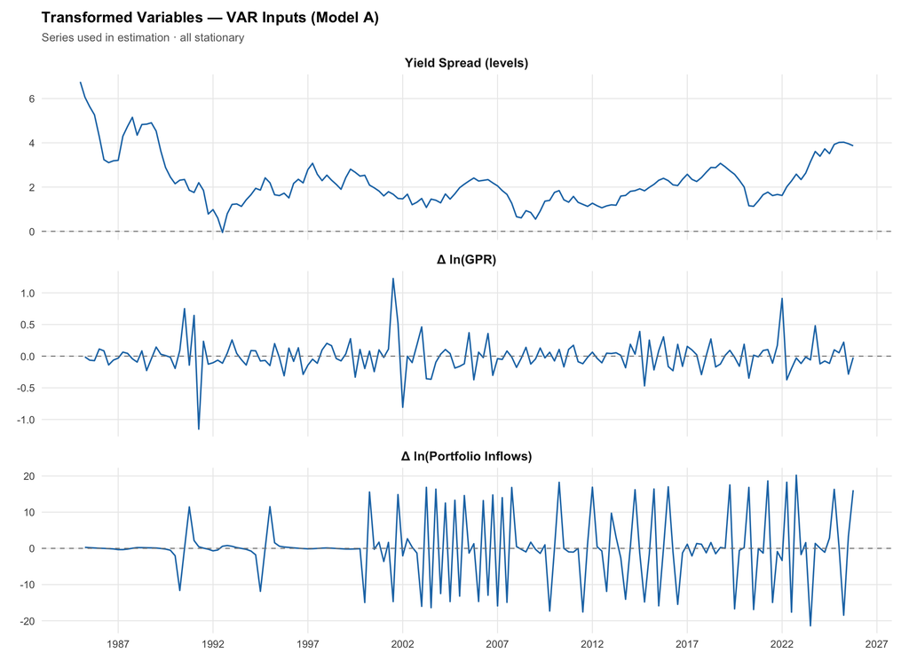

```r
df %>%
  dplyr::select(date, d_ln_pip, d_ln_gpr, spread) %>%
  pivot_longer(-date, names_to = "var", values_to = "val") %>%
  mutate(var = recode(var,
    d_ln_pip = "Δ ln(Portfolio Inflows)",
    d_ln_gpr = "Δ ln(GPR)",
    spread   = "Yield Spread (levels)"
  )) %>%
  ggplot(aes(x = date, y = val)) +
  geom_line(color = "#1f77b4", linewidth = 0.6) +
  geom_hline(yintercept = 0, linetype = "dashed",
             color = "grey50", linewidth = 0.4) +
  facet_wrap(~var, scales = "free_y", ncol = 1) +
  scale_x_date(date_breaks = "5 years", date_labels = "%Y") +
  labs(title    = "Transformed Variables — VAR Inputs (Model A)",
       subtitle = "Series used in estimation · all stationary",
       x = NULL, y = NULL) +
  theme_chf()
```

# 7 Unit Root Tests

We formally assess the stationarity properties of the time series using the Augmented Dickey–Fuller (ADF) unit root test. The ADF test evaluates whether a series follows a random walk process (non-stationary), where shocks have permanent effects, or whether it reverts toward a stable mean over time (stationary). The null hypothesis corresponds to the presence of a unit root, implying non-stationarity.

The ADF specification includes lagged differences of the dependent variable to account for serial correlation in the residuals. Including an appropriate number of lags is important because too few lags may leave residual autocorrelation, while too many lags may reduce estimation efficiency. The formal lag-selection procedure used in the VAR model is discussed separately in the following section.

```r
# ADF test results for all VAR variables
# Tests both levels and first differences to confirm correct transformation
# use run_adf_test function defined in Section 5.1

adf_all_variables <- bind_rows(
  run_adf_test(df$ln_pip,        "ln(Portfolio Inflows) — levels"),
  run_adf_test(df$ln_gpr,        "ln(GPR) — levels"),
  run_adf_test(df$spread,        "Yield Spread — levels"),
  run_adf_test(df$d_fx_reserves, "Δ FX Reserves — levels"),
  run_adf_test(df$d_ln_pip,      "Δ ln(Portfolio Inflows) — 1st difference"),
  run_adf_test(df$d_ln_gpr,      "Δ ln(GPR) — 1st difference")
) %>%
  mutate(
    Decision = ifelse(Decision == "Stationary",
                      "Stationary", "Non-stationary")
  )

adf_all_variables %>%
  gt() %>%
  tab_header(
    title    = md("**Table 2 — ADF Unit Root Tests**"),
    subtitle = md("*Drift specification · AIC lag selection · 5% significance threshold*")
  ) %>%
  tab_row_group(
    label = "First Differences",
    rows  = 5:6
  ) %>%
  tab_row_group(
    label = "Levels",
    rows  = 1:4
  ) %>%
  tab_style(
    style     = cell_text(weight = "bold", size = px(12)),
    locations = cells_row_groups()
  ) %>%
  cols_label(
    Variable = "Variable",
    ADF_stat = "ADF Statistic",
    CV_1pct  = "CV 1%",
    CV_5pct  = "CV 5%",
    CV_10pct = "CV 10%",
    Decision = "Decision"
  ) %>%
  cols_align(align = "left",   columns = Variable) %>%
  cols_align(align = "center", columns = c(ADF_stat, CV_1pct,
                                            CV_5pct, CV_10pct, Decision)) %>%
  cols_width(
    Variable ~ px(260),
    ADF_stat ~ px(100),
    CV_1pct  ~ px(70),
    CV_5pct  ~ px(70),
    CV_10pct ~ px(70),
    Decision ~ px(130)
  ) %>%
  tab_style(
    style     = cell_fill(color = "#f9f9f9"),
    locations = cells_body(rows = c(1, 3))
  ) %>%
  tab_style(
    style     = cell_fill(color = "#f0f6fb"),
    locations = cells_body(rows = 5:6)
  ) %>%
tab_style(
  style     = cell_text(color = "#1a5276"),
  locations = cells_body(
    columns = Decision,
    rows    = Decision == "Stationary"
  )
) %>%
tab_style(
  style     = cell_text(color = "#922b21"),
  locations = cells_body(
    columns = Decision,
    rows    = Decision == "Non-stationary"
  )
) %>%
  tab_style(
    style     = cell_borders(sides = "top",    color = "black", weight = px(2)),
    locations = cells_column_labels()
  ) %>%
  tab_style(
    style     = cell_borders(sides = "bottom", color = "black", weight = px(2)),
    locations = cells_column_labels()
  ) %>%
  tab_style(
    style     = cell_borders(sides = "bottom", color = "black", weight = px(2)),
    locations = cells_body(rows = 6)
  ) %>%
  tab_style(
    style     = cell_borders(sides = c("top", "bottom"),
                              color = "white", weight = px(0)),
    locations = cells_body(rows = c(1:3, 5))
  ) %>%
  tab_style(
    style     = cell_text(weight = "bold"),
    locations = cells_column_labels()
  ) %>%
  tab_source_note(
    md("*Note: H₀: unit root present. Reject H₀ if ADF statistic < CV 5% (−2.88). Variables in levels that are non-stationary are transformed to first differences before entering the VAR. The yield spread and Δ FX Reserves enter in levels since they are already stationary.*")
  ) %>%
  tab_options(
    table.font.size                 = px(13),
    table.border.top.style          = "hidden",
    table.border.bottom.style       = "hidden",
    row.striping.include_table_body = FALSE,
    column_labels.background.color  = "white",
    table_body.hlines.style         = "none",
    heading.border.bottom.style     = "none",
    row_group.background.color      = "white",
    row_group.border.top.color      = "black",
    row_group.border.bottom.color   = "black",
    table.width                     = pct(100)
  )
```

**Table 2 — ADF Unit Root Tests**

*Drift specification · AIC lag selection · 5% significance threshold*

| Variable | ADF Statistic | CV 1% | CV 5% | CV 10% | Decision |
| --- | --- | --- | --- | --- | --- |
| Levels |  |  |  |  |  |
| ln(Portfolio Inflows) — levels | -6.178 | -3.46 | -2.88 | -2.57 | Stationary |
| ln(GPR) — levels | -4.553 | -3.46 | -2.88 | -2.57 | Stationary |
| Yield Spread — levels | -3.569 | -3.46 | -2.88 | -2.57 | Stationary |
| Δ FX Reserves — levels | -6.610 | -3.46 | -2.88 | -2.57 | Stationary |
| First Differences |  |  |  |  |  |
| Δ ln(Portfolio Inflows) — 1st difference | -12.731 | -3.46 | -2.88 | -2.57 | Stationary |
| Δ ln(GPR) — 1st difference | -11.064 | -3.46 | -2.88 | -2.57 | Stationary |

Schwert, G.W. (1989). Tests for unit roots: A Monte Carlo investigation. *Journal of Business & Economic Statistics*, 7(2), 147–159. https://www.jstor.org/stable/1391432

# 8 VAR Lag Length Selection

We use the VARselect() function to determine the optimal lag length for the VAR models based on several standard information criteria: Akaike Information Criterion (AIC), Hannan–Quinn Criterion (HQ), Schwarz Criterion (SC/BIC), and the Final Prediction Error (FPE). The procedure evaluates lag lengths from 1 to 8 and computes each criterion for every specification.

The different criteria balance model fit and model complexity in different ways. The AIC is generally more permissive and tends to select longer lag structures, while the SC/BIC applies a stronger penalty for additional parameters and therefore favors more parsimonious models. The HQ criterion lies between these two approaches. The FPE criterion is closely related to the AIC and focuses on out-of-sample forecasting performance.

Lag selection is performed separately for Model A and Model B.

```r
# Model A: GPR → Spread → PIP (3 variables, 1985–2025)
# Cholesky identification ordering:
#   1. d_ln_gpr : global geopolitical index (most exogenous)
#   2. spread.  : slow-moving carry trade variable
#   3. d_ln_pip : endogenous safe-haven response

data_A <- df %>%
  filter(date >= as.Date("1985-01-01"),
         date <= as.Date("2025-10-01")) %>%
  dplyr::select(d_ln_gpr, spread, d_ln_pip) %>%
  na.omit()

cat("=== Model A — lag selection (3 variables) ===\n")
```

```
=== Model A — lag selection (3 variables) ===
```

```r
lag_A <- VARselect(data_A, lag.max = 8, type = "const")
print(lag_A$selection)
```

```
AIC(n)  HQ(n)  SC(n) FPE(n)
     5      3      1      5
```

```r
# Model B: GPR → Spread → ΔFX → PIP (4 variables, 1997–2025)

data_B <- df %>%
  filter(date >= as.Date("1997-01-01"),
         date <= as.Date("2025-10-01")) %>%
  dplyr::select(d_ln_gpr, spread, d_fx_reserves, d_ln_pip) %>%
  na.omit()

cat("\n=== Model B — lag selection (4 variables) ===\n")
```

```
=== Model B — lag selection (4 variables) ===
```

```r
lag_B <- VARselect(data_B, lag.max = 8, type = "const")
print(lag_B$selection)
```

```
AIC(n)  HQ(n)  SC(n) FPE(n)
     5      1      1      5
```

```r
p_A <- min(lag_A$selection["AIC(n)"], 4)
p_B <- min(lag_B$selection["AIC(n)"], 4)
cat("\nFinal lags — Model A:", p_A, "| Model B:", p_B, "\n")
```

```
Final lags — Model A: 4 | Model B: 4
```

The lag selection criteria point toward a relatively persistent dynamic structure. Both the AIC and FPE consistently select 5 lags for both models, which we cap at 4 (one full year) in order to preserve degrees of freedom given our sample of 164 quarterly observations. The stricter SC criterion instead prefers a single lag, reflecting its heavier penalty for model complexity. This disagreement across criteria is common in VAR applications with macroeconomic data and does not necessarily indicate a specification issue, but rather the usual trade-off between model fit and parsimony.

We adopt the AIC-based selection (capped at p = 4) as our baseline specification, since safe-haven capital flows are likely to adjust gradually and a one-year dynamic window is economically plausible in our setting. The SC-based lag specification is used as a robustness check in Section 11 to verify that the main results are not sensitive to lag length choice.

# 9 VAR Estimation

## 9.1 Model Specification

Following Definition 3.1 of the lecture notes, we estimate a VAR($p$) model where $y_t$ denotes an $n \times 1$ vector of endogenous variables. For Model A with $n = 3$ variables and $p = 4$ lags, the system is shown as follow:

$$y_t = c + \Phi_1 y_{t-1} + \Phi_2 y_{t-2} + \Phi_3 y_{t-3} + \Phi_4 y_{t-4} + \varepsilon_t
\tag{1}$$

where:

$$y_t = \begin{pmatrix} \Delta \ln(\text{GPR}_t) \\ \text{Spread}_t \\ \Delta \ln(\text{PIP}_t) \end{pmatrix}, \quad
c = \begin{pmatrix} c_1 \\ c_2 \\ c_3 \end{pmatrix}, \quad
\varepsilon_t = \begin{pmatrix} \varepsilon_{1,t} \\ \varepsilon_{2,t} \\ \varepsilon_{3,t} \end{pmatrix}$$

### 9.1.1 The Key Equation — Portfolio Inflows

Writing out the third row of Eq. (1) explicitly gives the equation that is central to our hypothesis:

$$\Delta \ln(\text{PIP}_t) = c_3
+ \sum_{j=1}^{4} \alpha_j \, \Delta \ln(\text{GPR}_{t-j})
+ \sum_{j=1}^{4} \beta_j \, \text{Spread}_{t-j}
+ \sum_{j=1}^{4} \gamma_j \, \Delta \ln(\text{PIP}_{t-j})
+ \varepsilon_{3,t}
\tag{2}$$

where $\alpha_j$ are the GPR coefficients capturing the safe-haven fear channel, $\beta_j$ are the yield spread coefficients capturing the carry trade channel, and lastly $\gamma_j$ capture the own persistence of portfolio inflows. Our main null hypothesis is:

$$H_0: \alpha_1 = \alpha_2 = \alpha_3 = \alpha_4 = 0 \quad \text{(no safe-haven effect)}$$
$$H_1: \alpha_j > 0 \text{ for at least one } j \quad \text{(safe-haven effect present)}$$

$H_0$ is tested jointly via the Granger causality F-test in Section 14, and individually via the coefficient significance tests in Section 9.2.

### 9.1.2 Structural Shocks

Following the lecture notation, the reduced-form residuals $\varepsilon_t$ are related to the structural shocks $\eta_t$ via:

Model B extends Eq. (1) to $n = 4$ variables by inserting $\Delta \text{FX}_t$ — the quarterly change in SNB foreign exchange reserves — between the yield spread and portfolio inflows:

$$y_t = \begin{pmatrix} \Delta \ln(\text{GPR}_t) \\ \text{Spread}_t \\ \Delta \text{FX}_t \\ \Delta \ln(\text{PIP}_t) \end{pmatrix}$$

The $\Phi_j$ matrices are now $(4 \times 4)$ and the system is estimated over a shorter sample 1997–2025 due to FX reserves data availability. Adding $\Delta \text{FX}_t$ absorbs mechanical capital flows generated by SNB interventions, providing a robustness check on whether the GPR coefficients $\alpha_j$ survive after controlling for central bank behavior and taken actions through out time.

### 9.1.4 Stability Condition

Following Eq. (3.8) of the lecture notes, the VAR is stable if and only if the eigenvalues of the companion matrix:

$$\Phi = \begin{bmatrix} \Phi_1 & \Phi_2 & \cdots & \Phi_p \\ I & 0 & \cdots & 0 \\ 0 & \ddots & & 0 \\ 0 & 0 & I & 0 \end{bmatrix}$$
lie strictly inside the unit circle. This condition is verified graphically in Section 9.4 for both models.

### 9.1.5 Lag Length Selection

Following Eq. (3.16) of the lecture notes, we select the lag length $p$ using the Akaike Information Criterion:

$$AIC = cst + \log|\hat{\Omega}| + \frac{2}{T}N$$

where $N = p \times n^2$ is the total number of estimated parameters. AIC selects $p = 5$ for both models, capped at $p = 4$ to preserve degrees of freedom given our sample size of $T = 164$ quarters. The lag selection procedure is documented in Section 8.

## 9.2 Model A — Main Model (1985–2025, 3 variables)

```r
var_A <- VAR(data_A, p = p_A, type = "const")
summary(var_A)
```

```
VAR Estimation Results:
=========================
Endogenous variables: d_ln_gpr, spread, d_ln_pip
Deterministic variables: const
Sample size: 159
Log Likelihood: -543.635
Roots of the characteristic polynomial:
0.8915 0.8459 0.8186 0.8186 0.7082 0.7082 0.6941 0.5629 0.5629 0.3971 0.2545 0.04433
Call:
VAR(y = data_A, p = p_A, type = "const")


Estimation results for equation d_ln_gpr:
=========================================
d_ln_gpr = d_ln_gpr.l1 + spread.l1 + d_ln_pip.l1 + d_ln_gpr.l2 + spread.l2 + d_ln_pip.l2 + d_ln_gpr.l3 + spread.l3 + d_ln_pip.l3 + d_ln_gpr.l4 + spread.l4 + d_ln_pip.l4 + const

             Estimate Std. Error t value Pr(>|t|)
d_ln_gpr.l1 -0.331708   0.082664  -4.013 9.56e-05 ***
spread.l1    0.037465   0.059878   0.626 0.532492
d_ln_pip.l1 -0.006073   0.002958  -2.053 0.041833 *
d_ln_gpr.l2 -0.186685   0.084337  -2.214 0.028410 *
spread.l2   -0.034172   0.091286  -0.374 0.708695
d_ln_pip.l2 -0.004865   0.003156  -1.542 0.125334
d_ln_gpr.l3 -0.291444   0.085261  -3.418 0.000817 ***
spread.l3   -0.049339   0.090760  -0.544 0.587531
d_ln_pip.l3 -0.001632   0.003243  -0.503 0.615580
d_ln_gpr.l4 -0.153852   0.083954  -1.833 0.068903 .
spread.l4    0.040452   0.057527   0.703 0.483057
d_ln_pip.l4 -0.003179   0.003006  -1.057 0.292122
const        0.013641   0.047282   0.289 0.773372
---
Signif. codes:  0 '***' 0.001 '**' 0.01 '*' 0.05 '.' 0.1 ' ' 1


Residual standard error: 0.2386 on 146 degrees of freedom
Multiple R-Squared: 0.163,  Adjusted R-squared: 0.09425
F-statistic:  2.37 on 12 and 146 DF,  p-value: 0.008108


Estimation results for equation spread:
```

[output cut: 50 more lines]

```
F-statistic: 13.01 on 12 and 146 DF,  p-value: < 2.2e-16



Covariance matrix of residuals:
          d_ln_gpr    spread d_ln_pip
d_ln_gpr  0.056948  0.001734  -0.1895
spread    0.001734  0.103571  -0.2617
d_ln_pip -0.189508 -0.261719  42.2833

Correlation matrix of residuals:
         d_ln_gpr   spread d_ln_pip
d_ln_gpr  1.00000  0.02257  -0.1221
spread    0.02257  1.00000  -0.1251
d_ln_pip -0.12212 -0.12506   1.0000
```

```r
roots_A <- roots(var_A)
cat("\nMax companion root:", round(max(roots_A), 4),
    "— Stable:", ifelse(max(roots_A) < 1, "YES ✓", "NO ✗"), "\n")
```

```
Max companion root: 0.8915 — Stable: YES ✓
```

Compute the table format for each variable:

```r
var_A <- VAR(data_A, p = p_A, type = "const")

tidy_var_equation <- function(var_model, eq_name) {
  coef_mat  <- coef(var_model)[[eq_name]]
  raw_terms <- rownames(coef_mat)

  tibble(
    raw          = raw_terms,
    Estimate     = paste0(
                     round(coef_mat[, "Estimate"], 3),
                     as.character(symnum(coef_mat[, "Pr(>|t|)"],
                       cutpoints = c(0, .001, .01, .05, .1, 1),
                       symbols   = c("***", "**", "*", ".", "")))
                   ),
    `Std. Error` = round(coef_mat[, "Std. Error"], 3),
    `t value`    = round(coef_mat[, "t value"],    3),
    `p value`    = round(coef_mat[, "Pr(>|t|)"],   4)
  ) %>%
  mutate(
    lag_group = case_when(
      grepl("\\.l(\\d+)$", raw) ~ paste0("Lag ", gsub(".*\\.l(\\d+)$", "\\1", raw)),
      raw == "const"            ~ "Constant",
      TRUE                      ~ "Other"
    ),
    Term = raw %>%
      gsub("\\.l\\d+$",     "",              .) %>%
      gsub("d_ln_gpr",      "Δ ln(GPR)",    .) %>%
      gsub("d_ln_pip",      "Δ ln(Inflows)"  ,.) %>%
      gsub("spread",        "Yield Spread",  .) %>%
      gsub("d_fx_reserves", "Δ FX Reserves", .) %>%
      gsub("const",         "Constant",      .)
  ) %>%
  dplyr::select(lag_group, Term, Estimate, `Std. Error`, `t value`, `p value`)
}

equation_captions <- c(
  d_ln_gpr = "Geopolitical risk is highly persistent. Its own lagged values remain statistically significant at horizons 1, 2, and 3 quarters (coefficients: −0.332, −0.187, −0.291), indicating that geopolitical shocks dissipate gradually over time rather than disappearing immediately. By contrast, neither the yield spread nor portfolio inflows exhibit statistically significant effects in the GPR equation, supporting the treatment of GPR as the most exogenous variable in the VAR ordering.",
  spread   = "The yield spread is highly persistent and is mainly explained by its own past values. The lag-1 coefficient is strongly significant at 1.157\\*\\*\\*, while the significant coefficients at lags 2 and 4 suggest that the spread adjusts gradually over time. In contrast, neither GPR nor portfolio inflows are statistically significant at any lag. This indicates that interest rate differentials evolve largely independently from geopolitical shocks and safe-haven capital flows, supporting the use of the yield spread as a control variable in the VAR model.",
  d_ln_pip = "This is the central equation of the VAR model. GPR shocks at lags 1 and 4 are individually significant, providing preliminary evidence of a safe-haven effect. As reduced-form coefficients are not economically interpretable in isolation, their magnitude and timing are assessed formally via the impulse response functions and forecast-error variance decomposition reported below, rather than from the coefficient values themselves. By contrast, the yield spread is not statistically significant at any lag. Portfolio inflows display as well strong own dynamics, with highly significant negative coefficients at lags 1–3. Overall, the model explains approximately 52% of the variation in inflows (R² = 0.517)."
)

equation_labels <- c(
  d_ln_gpr = "Δ ln(GPR)",
  spread   = "Yield Spread",
  d_ln_pip = "Δ ln(Portfolio Inflows)"
)

for (eq in c("d_ln_gpr", "spread", "d_ln_pip")) {

  equation_tbl <- tidy_var_equation(var_A, eq)
  lag_groups   <- equation_tbl$lag_group

  gt_output <- equation_tbl %>%
    dplyr::select(-lag_group) %>%
    gt() %>%
    tab_header(
      title    = md("**Model A — VAR Estimation Results**"),
      subtitle = md(paste0("*Variable: ", equation_labels[eq], "*"))
    ) %>%
    tab_row_group(label = "Constant", rows = which(lag_groups == "Constant")) %>%
    tab_row_group(label = "Lag 4",    rows = which(lag_groups == "Lag 4"))    %>%
    tab_row_group(label = "Lag 3",    rows = which(lag_groups == "Lag 3"))    %>%
    tab_row_group(label = "Lag 2",    rows = which(lag_groups == "Lag 2"))    %>%
    tab_row_group(label = "Lag 1",    rows = which(lag_groups == "Lag 1"))    %>%
    tab_style(
      style     = cell_text(weight = "bold"),
      locations = cells_row_groups()
    ) %>%
    tab_style(
      style     = cell_text(weight = "bold"),
      locations = cells_column_labels()
    ) %>%
    tab_style(
      style     = cell_borders(sides = "top",    color = "black", weight = px(2)),
      locations = cells_column_labels()
    ) %>%
    tab_style(
      style     = cell_borders(sides = "bottom", color = "black", weight = px(2)),
      locations = cells_column_labels()
    ) %>%
    tab_style(
      style     = cell_borders(sides = "bottom", color = "black", weight = px(2)),
      locations = cells_body(rows = nrow(equation_tbl))
    ) %>%
    tab_source_note(md(paste0("*", equation_captions[eq], "*"))) %>%
    tab_source_note(
      md("*Significance: \\*\\*\\* p<0.001 · \\*\\* p<0.01 · \\* p<0.05 · . p<0.1*")
    ) %>%
    tab_options(
      table.font.size                 = px(13),
      table.border.top.style          = "hidden",
      table.border.bottom.style       = "hidden",
      row_group.background.color      = "#f0f0f0",
      row_group.font.size             = px(12),
      row.striping.include_table_body = FALSE,
      column_labels.background.color  = "white"
    )

  print(gt_output)   # works in both RStudio viewer and Quarto HTML render
  cat("\n\n")
}
```

**Model A — VAR Estimation Results**

*Variable: Δ ln(GPR)*

| Term | Estimate | Std. Error | t value | p value |
| --- | --- | --- | --- | --- |
| Lag 1 |  |  |  |  |
| Δ ln(GPR) | -0.332*** | 0.083 | -4.013 | 0.0001 |
| Yield Spread | 0.037 | 0.060 | 0.626 | 0.5325 |
| Δ ln(Inflows) | -0.006* | 0.003 | -2.053 | 0.0418 |
| Lag 2 |  |  |  |  |
| Δ ln(GPR) | -0.187* | 0.084 | -2.214 | 0.0284 |
| Yield Spread | -0.034 | 0.091 | -0.374 | 0.7087 |
| Δ ln(Inflows) | -0.005 | 0.003 | -1.542 | 0.1253 |
| Lag 3 |  |  |  |  |
| Δ ln(GPR) | -0.291*** | 0.085 | -3.418 | 0.0008 |
| Yield Spread | -0.049 | 0.091 | -0.544 | 0.5875 |
| Δ ln(Inflows) | -0.002 | 0.003 | -0.503 | 0.6156 |
| Lag 4 |  |  |  |  |
| Δ ln(GPR) | -0.154. | 0.084 | -1.833 | 0.0689 |
| Yield Spread | 0.04 | 0.058 | 0.703 | 0.4831 |
| Δ ln(Inflows) | -0.003 | 0.003 | -1.057 | 0.2921 |
| Constant |  |  |  |  |
| Constant | 0.014 | 0.047 | 0.289 | 0.7734 |

**Model A — VAR Estimation Results**

*Variable: Yield Spread*

| Term | Estimate | Std. Error | t value | p value |
| --- | --- | --- | --- | --- |
| Lag 1 |  |  |  |  |
| Δ ln(GPR) | -0.108 | 0.111 | -0.965 | 0.3360 |
| Yield Spread | 1.157*** | 0.081 | 14.331 | 0.0000 |
| Δ ln(Inflows) | -0.004 | 0.004 | -0.939 | 0.3493 |
| Lag 2 |  |  |  |  |
| Δ ln(GPR) | 0.148 | 0.114 | 1.305 | 0.1941 |
| Yield Spread | -0.29* | 0.123 | -2.353 | 0.0200 |
| Δ ln(Inflows) | 0.003 | 0.004 | 0.771 | 0.4417 |
| Lag 3 |  |  |  |  |
| Δ ln(GPR) | -0.088 | 0.115 | -0.765 | 0.4457 |
| Yield Spread | 0.228. | 0.122 | 1.864 | 0.0643 |
| Δ ln(Inflows) | 0.002 | 0.004 | 0.384 | 0.7019 |
| Lag 4 |  |  |  |  |
| Δ ln(GPR) | 0.047 | 0.113 | 0.413 | 0.6805 |
| Yield Spread | -0.175* | 0.078 | -2.252 | 0.0258 |
| Δ ln(Inflows) | 0.002 | 0.004 | 0.546 | 0.5860 |
| Constant |  |  |  |  |
| Constant | 0.17** | 0.064 | 2.671 | 0.0084 |

*The yield spread is highly persistent and is mainly explained by its own past values. The lag-1 coefficient is strongly significant at 1.157***, while the significant coefficients at lags 2 and 4 suggest that the spread adjusts gradually over time. In contrast, neither GPR nor portfolio inflows are statistically significant at any lag. This indicates that interest rate differentials evolve largely independently from geopolitical shocks and safe-haven capital flows, supporting the use of the yield spread as a control variable in the VAR model.*  
*Significance: *** p<0.001 · ** p<0.01 · * p<0.05 · . p<0.1*

**Model A — VAR Estimation Results**

*Variable: Δ ln(Portfolio Inflows)*

| Term | Estimate | Std. Error | t value | p value |
| --- | --- | --- | --- | --- |
| Lag 1 |  |  |  |  |
| Δ ln(GPR) | 4.808* | 2.252 | 2.135 | 0.0345 |
| Yield Spread | -0.221 | 1.632 | -0.136 | 0.8922 |
| Δ ln(Inflows) | -0.512*** | 0.081 | -6.356 | 0.0000 |
| Lag 2 |  |  |  |  |
| Δ ln(GPR) | -2.629 | 2.298 | -1.144 | 0.2545 |
| Yield Spread | -0.741 | 2.487 | -0.298 | 0.7662 |
| Δ ln(Inflows) | -0.375*** | 0.086 | -4.356 | 0.0000 |
| Lag 3 |  |  |  |  |
| Δ ln(GPR) | 3.436 | 2.323 | 1.479 | 0.1413 |
| Yield Spread | 1.826 | 2.473 | 0.738 | 0.4616 |
| Δ ln(Inflows) | -0.468*** | 0.088 | -5.298 | 0.0000 |
| Lag 4 |  |  |  |  |
| Δ ln(GPR) | 8.637*** | 2.288 | 3.775 | 0.0002 |
| Yield Spread | -0.629 | 1.568 | -0.401 | 0.6888 |
| Δ ln(Inflows) | 0.156. | 0.082 | 1.902 | 0.0591 |
| Constant |  |  |  |  |
| Constant | -0.599 | 1.288 | -0.465 | 0.6429 |

*This is the central equation of the VAR model. GPR shocks at lags 1 and 4 are individually significant, providing preliminary evidence of a safe-haven effect. As reduced-form coefficients are not economically interpretable in isolation, their magnitude and timing are assessed formally via the impulse response functions and forecast-error variance decomposition reported below, rather than from the coefficient values themselves. By contrast, the yield spread is not statistically significant at any lag. Portfolio inflows display as well strong own dynamics, with highly significant negative coefficients at lags 1–3. Overall, the model explains approximately 52% of the variation in inflows (R² = 0.517).*  
*Significance: *** p<0.001 · ** p<0.01 · * p<0.05 · . p<0.1*

```r
# Goodness of fit table
goodness_of_fit_tbl <- sapply(c("d_ln_gpr", "spread", "d_ln_pip"), function(eq) {
  model_summary <- summary(var_A$varresult[[eq]])
  c(R2     = round(model_summary$r.squared,     3),
    Adj.R2 = round(model_summary$adj.r.squared, 3),
    F.stat = round(model_summary$fstatistic[1], 2))
}) %>%
  t() %>%
  as_tibble(rownames = "Equation") %>%
  mutate(Equation = c("Δ ln(GPR)", "Yield Spread", "Δ ln(Portfolio Inflows)"))

gof_output <- goodness_of_fit_tbl %>%
  gt() %>%
  tab_header(title = md("**Model A — Goodness of Fit**")) %>%
  tab_style(
    style     = cell_text(weight = "bold"),
    locations = cells_column_labels()
  ) %>%
  tab_style(
    style     = cell_borders(sides = "top",    color = "black", weight = px(2)),
    locations = cells_column_labels()
  ) %>%
  tab_style(
    style     = cell_borders(sides = "bottom", color = "black", weight = px(2)),
    locations = cells_column_labels()
  ) %>%
  tab_style(
    style     = cell_borders(sides = "bottom", color = "black", weight = px(2)),
    locations = cells_body(rows = nrow(goodness_of_fit_tbl))
  ) %>%
  tab_source_note(
    md("*R² and Adjusted R² measure the share of variation explained by the model. F-stat tests joint significance of all regressors.*")
  ) %>%
  tab_options(
    table.font.size                 = px(13),
    table.border.top.style          = "hidden",
    table.border.bottom.style       = "hidden",
    row.striping.include_table_body = FALSE,
    column_labels.background.color  = "white"
  )

print(gof_output)
```

**Model A — Goodness of Fit**

| Equation | R2 | Adj.R2 | F.stat.value |
| --- | --- | --- | --- |
| Δ ln(GPR) | 0.163 | 0.094 | 2.37 |
| Yield Spread | 0.897 | 0.889 | 106.29 |
| Δ ln(Portfolio Inflows) | 0.517 | 0.477 | 13.01 |

*R² and Adjusted R² measure the share of variation explained by the model. F-stat tests joint significance of all regressors.*

```r
cat("\n\n")
```

```r
# Stability check
companion_roots_A <- roots(var_A)
cat("Max companion root:", round(max(companion_roots_A), 4),
    "— Stable:", ifelse(max(companion_roots_A) < 1, "YES ✓", "NO ✗"), "\n")
```

Max companion root: 0.8915 — Stable: YES ✓

## 9.3 Model B — Robustness (1997–2025, 4 variables)

```r
var_B <- VAR(data_B, p = p_B, type = "const")
summary(var_B)
```

```
VAR Estimation Results:
=========================
Endogenous variables: d_ln_gpr, spread, d_fx_reserves, d_ln_pip
Deterministic variables: const
Sample size: 112
Log Likelihood: -868.79
Roots of the characteristic polynomial:
0.8962 0.8923 0.8563 0.8563 0.7487 0.7487 0.7241 0.7241 0.7024 0.6805 0.6805 0.6229 0.6229 0.5336 0.5336 0.3243
Call:
VAR(y = data_B, p = p_B, type = "const")


Estimation results for equation d_ln_gpr:
=========================================
d_ln_gpr = d_ln_gpr.l1 + spread.l1 + d_fx_reserves.l1 + d_ln_pip.l1 + d_ln_gpr.l2 + spread.l2 + d_fx_reserves.l2 + d_ln_pip.l2 + d_ln_gpr.l3 + spread.l3 + d_fx_reserves.l3 + d_ln_pip.l3 + d_ln_gpr.l4 + spread.l4 + d_fx_reserves.l4 + d_ln_pip.l4 + const

                   Estimate Std. Error t value Pr(>|t|)
d_ln_gpr.l1      -2.751e-01  1.032e-01  -2.665  0.00905 **
spread.l1         6.379e-02  9.949e-02   0.641  0.52294
d_fx_reserves.l1 -8.635e-04  9.314e-04  -0.927  0.35624
d_ln_pip.l1      -4.880e-03  3.366e-03  -1.450  0.15040
d_ln_gpr.l2      -2.457e-01  1.055e-01  -2.329  0.02196 *
spread.l2        -1.215e-01  1.481e-01  -0.821  0.41393
d_fx_reserves.l2  2.741e-05  9.006e-04   0.030  0.97579
d_ln_pip.l2      -2.905e-03  3.573e-03  -0.813  0.41831
d_ln_gpr.l3      -2.680e-01  1.087e-01  -2.467  0.01542 *
spread.l3         2.341e-02  1.455e-01   0.161  0.87246
d_fx_reserves.l3  2.991e-04  8.983e-04   0.333  0.73988
d_ln_pip.l3       5.549e-04  3.675e-03   0.151  0.88031
d_ln_gpr.l4      -1.421e-01  1.055e-01  -1.346  0.18139
spread.l4         3.859e-02  9.954e-02   0.388  0.69916
d_fx_reserves.l4  1.101e-03  9.207e-04   1.196  0.23475
d_ln_pip.l4      -2.557e-03  3.396e-03  -0.753  0.45327
const             4.028e-03  7.613e-02   0.053  0.95791
---
Signif. codes:  0 '***' 0.001 '**' 0.01 '*' 0.05 '.' 0.1 ' ' 1


Residual standard error: 0.2444 on 95 degrees of freedom
Multiple R-Squared: 0.1758, Adjusted R-squared: 0.03693
```

[output cut: 95 more lines]

```


Covariance matrix of residuals:
               d_ln_gpr    spread d_fx_reserves d_ln_pip
d_ln_gpr       0.059739  0.007661       -0.6727  -0.3446
spread         0.007661  0.062406       -1.0222  -0.2340
d_fx_reserves -0.672727 -1.022164      720.8760  -3.1042
d_ln_pip      -0.344610 -0.233979       -3.1042  51.0950

Correlation matrix of residuals:
              d_ln_gpr  spread d_fx_reserves d_ln_pip
d_ln_gpr        1.0000  0.1255      -0.10251 -0.19725
spread          0.1255  1.0000      -0.15240 -0.13103
d_fx_reserves  -0.1025 -0.1524       1.00000 -0.01617
d_ln_pip       -0.1972 -0.1310      -0.01617  1.00000
```

```r
roots_B <- roots(var_B)
cat("\nMax companion root:", round(max(roots_B), 4),
    "— Stable:", ifelse(max(roots_B) < 1, "YES ✓", "NO ✗"), "\n")
```

```
Max companion root: 0.8962 — Stable: YES ✓
```

Compute a table for each variable:

```r
var_B <- VAR(data_B, p = p_B, type = "const")

tidy_var_equation_B <- function(var_model, eq_name) {
  coef_mat  <- coef(var_model)[[eq_name]]
  raw_terms <- rownames(coef_mat)
  pvals     <- coef_mat[, "Pr(>|t|)"]
  stars     <- as.character(symnum(pvals,
                  cutpoints = c(0, .001, .01, .05, .1, 1),
                  symbols   = c("***", "**", "*", ".", "")))

  tibble(
    raw          = raw_terms,
    Term         = raw_terms %>%
                     gsub("\\.l\\d+$",     "",              .) %>%
                     gsub("d_ln_gpr",      "Δ ln(GPR)",    .) %>%
                     gsub("d_ln_pip",      "Δ ln(Inflows)", .) %>%
                     gsub("spread",        "Yield Spread",  .) %>%
                     gsub("d_fx_reserves", "Δ FX Reserves", .) %>%
                     gsub("const",         "Constant",      .),
    Estimate     = paste0(round(coef_mat[, "Estimate"], 3), stars),
    `Std. Error` = round(coef_mat[, "Std. Error"], 3),
    `t value`    = round(coef_mat[, "t value"],    3),
    `p value`    = round(pvals, 4),
    lag_group    = case_when(
      grepl("\\.l(\\d+)$", raw_terms) ~
        paste0("Lag ", gsub(".*\\.l(\\d+)$", "\\1", raw_terms)),
      raw_terms == "const" ~ "Constant",
      TRUE                 ~ "Other"
    )
  ) %>%
  dplyr::select(lag_group, Term, Estimate,
                `Std. Error`, `t value`, `p value`)
}

equation_captions_B <- c(
  d_ln_gpr = "Geopolitical risk remains persistent in Model B, with significant own lags at quarters 1 (-0.275), 2 (-0.246), and 3 (-0.268). Adding FX reserves as an additional control does not materially change the dynamics observed in Model A. Neither the yield spread, FX reserves, nor portfolio inflows are statistically significant in the GPR equation at any lag, supporting the treatment of GPR as the most exogenous variable in the VAR system. The results therefore suggest that geopolitical risk evolves largely independently from Swiss financial variables and SNB intervention activity.",
  spread   = "As in Model A, the yield spread is primarily explained by its own past values, with a highly significant lag-1 coefficient of 1.142\\*\\*\\*. The additional control introduced in Model B does not materially alter this result. Neither FX reserves nor portfolio inflows significantly predict the spread at any lag. GPR is only marginally significant at lag 1 (-0.188.), suggesting at most a limited short-run relationship between geopolitical risk and interest rate differentials. Overall, the results indicate that the carry-trade channel remains largely independent from Swiss safe-haven flows and SNB intervention dynamics within the VAR system.",
  d_fx_reserves = "FX reserves are only weakly explained by the VAR variables, consistent with the discretionary nature of SNB intervention policy. None of the GPR or yield spread coefficients are statistically significant at conventional levels. The only clearly significant effect is the own lag at quarter 3 (0.270\\*\\*), indicating limited persistence in reserve dynamics. Portfolio inflows display marginally negative effects at lags 3 and 4 (-0.789. and -0.671.), although these remain weakly significant. Overall, the relatively low explanatory power of this equation suggests that SNB reserve changes are difficult to predict using macro-financial variables alone.",
  d_ln_pip = "The safe-haven effect remains present in Model B after controlling for SNB FX reserve interventions. GPR at at lags 1 and 4 remains significant, consistent with Model A. As Model A, the economic magnitude of this effect is evaluated via the impulse response functions and forecast-error variance decomposition rather than from the individual reduced-form coefficients. FX reserves display a small positive effect at lag 4, suggesting limited interaction between SNB interventions and inflows. Portfolio inflows also retain strong own dynamics through highly significant negative coefficients at lags 1–3. Overall, the model explains approximately 60% of the variation in inflows (R² = 0.603), an improvement over Model A."
)

equation_labels_B <- c(
  d_ln_gpr      = "Δ ln(GPR)",
  spread        = "Yield Spread",
  d_fx_reserves = "Δ FX Reserves",
  d_ln_pip      = "Δ ln(Portfolio Inflows)"
)

for (eq in c("d_ln_gpr", "spread", "d_fx_reserves", "d_ln_pip")) {

  equation_tbl_B <- tidy_var_equation_B(var_B, eq)
  lag_groups_B   <- equation_tbl_B$lag_group

  gt_output_B <- equation_tbl_B %>%
    dplyr::select(-lag_group) %>%
    gt() %>%
    tab_header(
      title    = md("**Model B — VAR Estimation Results**"),
      subtitle = md(paste0("*Variable: ", equation_labels_B[eq], "*"))
    ) %>%
    tab_row_group(label = "Constant", rows = which(lag_groups_B == "Constant")) %>%
    tab_row_group(label = "Lag 4",    rows = which(lag_groups_B == "Lag 4"))    %>%
    tab_row_group(label = "Lag 3",    rows = which(lag_groups_B == "Lag 3"))    %>%
    tab_row_group(label = "Lag 2",    rows = which(lag_groups_B == "Lag 2"))    %>%
    tab_row_group(label = "Lag 1",    rows = which(lag_groups_B == "Lag 1"))    %>%
    cols_align(align = "right",
               columns = c(Estimate, `Std. Error`, `t value`, `p value`)) %>%
    tab_style(
      style     = cell_text(weight = "bold"),
      locations = cells_row_groups()
    ) %>%
    tab_style(
      style     = cell_text(weight = "bold"),
      locations = cells_column_labels()
    ) %>%
    tab_style(
      style     = cell_borders(sides = "top",    color = "black", weight = px(2)),
      locations = cells_column_labels()
    ) %>%
    tab_style(
      style     = cell_borders(sides = "bottom", color = "black", weight = px(2)),
      locations = cells_column_labels()
    ) %>%
    tab_style(
      style     = cell_borders(sides = "bottom", color = "black", weight = px(2)),
      locations = cells_body(rows = nrow(equation_tbl_B))
    ) %>%
    tab_source_note(md(paste0("*", equation_captions_B[eq], "*"))) %>%
    tab_source_note(
      md("*Significance: \\*\\*\\* p<0.001 · \\*\\* p<0.01 · \\* p<0.05 · . p<0.1*")
    ) %>%
    tab_options(
      table.font.size                 = px(13),
      table.border.top.style          = "hidden",
      table.border.bottom.style       = "hidden",
      row_group.background.color      = "#f0f0f0",
      row_group.font.size             = px(12),
      row.striping.include_table_body = FALSE,
      column_labels.background.color  = "white"
    )

  print(gt_output_B)
  cat("<br><br>")
}
```

**Model B — VAR Estimation Results**

*Variable: Δ ln(GPR)*

| Term | Estimate | Std. Error | t value | p value |
| --- | --- | --- | --- | --- |
| Lag 1 |  |  |  |  |
| Δ ln(GPR) | -0.275** | 0.103 | -2.665 | 0.0091 |
| Yield Spread | 0.064 | 0.099 | 0.641 | 0.5229 |
| Δ FX Reserves | -0.001 | 0.001 | -0.927 | 0.3562 |
| Δ ln(Inflows) | -0.005 | 0.003 | -1.450 | 0.1504 |
| Lag 2 |  |  |  |  |
| Δ ln(GPR) | -0.246* | 0.105 | -2.329 | 0.0220 |
| Yield Spread | -0.122 | 0.148 | -0.821 | 0.4139 |
| Δ FX Reserves | 0 | 0.001 | 0.030 | 0.9758 |
| Δ ln(Inflows) | -0.003 | 0.004 | -0.813 | 0.4183 |
| Lag 3 |  |  |  |  |
| Δ ln(GPR) | -0.268* | 0.109 | -2.467 | 0.0154 |
| Yield Spread | 0.023 | 0.145 | 0.161 | 0.8725 |
| Δ FX Reserves | 0 | 0.001 | 0.333 | 0.7399 |
| Δ ln(Inflows) | 0.001 | 0.004 | 0.151 | 0.8803 |
| Lag 4 |  |  |  |  |
| Δ ln(GPR) | -0.142 | 0.106 | -1.346 | 0.1814 |
| Yield Spread | 0.039 | 0.100 | 0.388 | 0.6992 |
| Δ FX Reserves | 0.001 | 0.001 | 1.196 | 0.2347 |
| Δ ln(Inflows) | -0.003 | 0.003 | -0.753 | 0.4533 |
| Constant |  |  |  |  |
| Constant | 0.004 | 0.076 | 0.053 | 0.9579 |

*Geopolitical risk remains persistent in Model B, with significant own lags at quarters 1 (-0.275), 2 (-0.246), and 3 (-0.268). Adding FX reserves as an additional control does not materially change the dynamics observed in Model A. Neither the yield spread, FX reserves, nor portfolio inflows are statistically significant in the GPR equation at any lag, supporting the treatment of GPR as the most exogenous variable in the VAR system. The results therefore suggest that geopolitical risk evolves largely independently from Swiss financial variables and SNB intervention activity.*  
*Significance: *** p<0.001 · ** p<0.01 · * p<0.05 · . p<0.1*

**Model B — VAR Estimation Results**

*Variable: Yield Spread*

| Term | Estimate | Std. Error | t value | p value |
| --- | --- | --- | --- | --- |
| Lag 1 |  |  |  |  |
| Δ ln(GPR) | -0.188. | 0.106 | -1.778 | 0.0785 |
| Yield Spread | 1.142*** | 0.102 | 11.231 | 0.0000 |
| Δ FX Reserves | -0.001 | 0.001 | -0.685 | 0.4948 |
| Δ ln(Inflows) | -0.002 | 0.003 | -0.461 | 0.6461 |
| Lag 2 |  |  |  |  |
| Δ ln(GPR) | 0.088 | 0.108 | 0.813 | 0.4184 |
| Yield Spread | -0.206 | 0.151 | -1.364 | 0.1759 |
| Δ FX Reserves | 0 | 0.001 | 0.001 | 0.9993 |
| Δ ln(Inflows) | 0.003 | 0.004 | 0.936 | 0.3516 |
| Lag 3 |  |  |  |  |
| Δ ln(GPR) | -0.079 | 0.111 | -0.715 | 0.4764 |
| Yield Spread | 0.198 | 0.149 | 1.332 | 0.1860 |
| Δ FX Reserves | 0 | 0.001 | 0.350 | 0.7274 |
| Δ ln(Inflows) | 0.004 | 0.004 | 1.023 | 0.3090 |
| Lag 4 |  |  |  |  |
| Δ ln(GPR) | -0.05 | 0.108 | -0.464 | 0.6439 |
| Yield Spread | -0.2. | 0.102 | -1.966 | 0.0522 |
| Δ FX Reserves | 0 | 0.001 | -0.405 | 0.6860 |
| Δ ln(Inflows) | 0.005 | 0.003 | 1.492 | 0.1390 |
| Constant |  |  |  |  |
| Constant | 0.148. | 0.078 | 1.905 | 0.0598 |

*As in Model A, the yield spread is primarily explained by its own past values, with a highly significant lag-1 coefficient of 1.142***. The additional control introduced in Model B does not materially alter this result. Neither FX reserves nor portfolio inflows significantly predict the spread at any lag. GPR is only marginally significant at lag 1 (-0.188.), suggesting at most a limited short-run relationship between geopolitical risk and interest rate differentials. Overall, the results indicate that the carry-trade channel remains largely independent from Swiss safe-haven flows and SNB intervention dynamics within the VAR system.*  
*Significance: *** p<0.001 · ** p<0.01 · * p<0.05 · . p<0.1*

**Model B — VAR Estimation Results**

*Variable: Δ FX Reserves*

| Term | Estimate | Std. Error | t value | p value |
| --- | --- | --- | --- | --- |
| Lag 1 |  |  |  |  |
| Δ ln(GPR) | -2.912 | 11.339 | -0.257 | 0.7979 |
| Yield Spread | -11.236 | 10.929 | -1.028 | 0.3065 |
| Δ FX Reserves | 0.105 | 0.102 | 1.026 | 0.3075 |
| Δ ln(Inflows) | -0.288 | 0.370 | -0.779 | 0.4379 |
| Lag 2 |  |  |  |  |
| Δ ln(GPR) | -16.715 | 11.585 | -1.443 | 0.1524 |
| Yield Spread | 18.802 | 16.266 | 1.156 | 0.2506 |
| Δ FX Reserves | -0.017 | 0.099 | -0.175 | 0.8614 |
| Δ ln(Inflows) | -0.547 | 0.393 | -1.394 | 0.1667 |
| Lag 3 |  |  |  |  |
| Δ ln(GPR) | -5.908 | 11.935 | -0.495 | 0.6218 |
| Yield Spread | -9.622 | 15.978 | -0.602 | 0.5485 |
| Δ FX Reserves | 0.27** | 0.099 | 2.737 | 0.0074 |
| Δ ln(Inflows) | -0.789. | 0.404 | -1.954 | 0.0537 |
| Lag 4 |  |  |  |  |
| Δ ln(GPR) | -12.378 | 11.591 | -1.068 | 0.2883 |
| Yield Spread | 0.661 | 10.935 | 0.060 | 0.9519 |
| Δ FX Reserves | 0.009 | 0.101 | 0.085 | 0.9322 |
| Δ ln(Inflows) | -0.671. | 0.373 | -1.799 | 0.0752 |
| Constant |  |  |  |  |
| Constant | 7.053 | 8.362 | 0.843 | 0.4011 |

*FX reserves are only weakly explained by the VAR variables, consistent with the discretionary nature of SNB intervention policy. None of the GPR or yield spread coefficients are statistically significant at conventional levels. The only clearly significant effect is the own lag at quarter 3 (0.270**), indicating limited persistence in reserve dynamics. Portfolio inflows display marginally negative effects at lags 3 and 4 (-0.789. and -0.671.), although these remain weakly significant. Overall, the relatively low explanatory power of this equation suggests that SNB reserve changes are difficult to predict using macro-financial variables alone.*  
*Significance: *** p<0.001 · ** p<0.01 · * p<0.05 · . p<0.1*

**Model B — VAR Estimation Results**

*Variable: Δ ln(Portfolio Inflows)*

| Term | Estimate | Std. Error | t value | p value |
| --- | --- | --- | --- | --- |
| Lag 1 |  |  |  |  |
| Δ ln(GPR) | 5.389. | 3.019 | 1.785 | 0.0774 |
| Yield Spread | -2.944 | 2.910 | -1.012 | 0.3142 |
| Δ FX Reserves | -0.032 | 0.027 | -1.166 | 0.2465 |
| Δ ln(Inflows) | -0.569*** | 0.098 | -5.784 | 0.0000 |
| Lag 2 |  |  |  |  |
| Δ ln(GPR) | -5.556. | 3.084 | -1.801 | 0.0748 |
| Yield Spread | 2.486 | 4.331 | 0.574 | 0.5672 |
| Δ FX Reserves | 0.016 | 0.026 | 0.591 | 0.5561 |
| Δ ln(Inflows) | -0.442*** | 0.105 | -4.230 | 0.0001 |
| Lag 3 |  |  |  |  |
| Δ ln(GPR) | 3.612 | 3.178 | 1.137 | 0.2586 |
| Yield Spread | 1.348 | 4.254 | 0.317 | 0.7521 |
| Δ FX Reserves | -0.006 | 0.026 | -0.219 | 0.8273 |
| Δ ln(Inflows) | -0.521*** | 0.107 | -4.843 | 0.0000 |
| Lag 4 |  |  |  |  |
| Δ ln(GPR) | 9.881** | 3.086 | 3.202 | 0.0019 |
| Yield Spread | 0.314 | 2.911 | 0.108 | 0.9143 |
| Δ FX Reserves | 0.063* | 0.027 | 2.355 | 0.0206 |
| Δ ln(Inflows) | 0.114 | 0.099 | 1.149 | 0.2534 |
| Constant |  |  |  |  |
| Constant | -2.795 | 2.226 | -1.255 | 0.2124 |